# 課題補足資料

## データセット

データセットは[dataset](https://databox.naist.jp/remote.php/webdav/isc-share/startup2020/配布資料/学習班/dataset/dataset.npz)にnumpyのnpz形式で保存してある．以下のようにロードして使える．

```
15
15
100
100
```

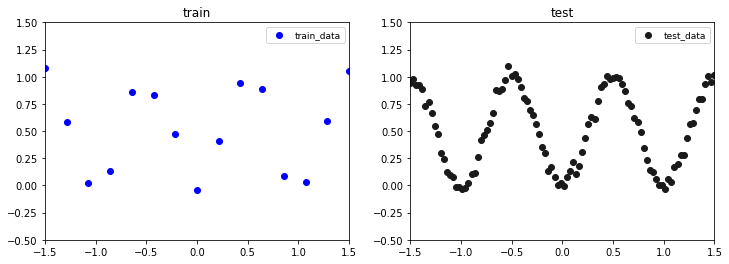

```python
# %matplotlib inline
import numpy as np
import matplotlib.pyplot as plt

dataset = np.load('dataset.npz')

#トレーニングデータ
x_train = dataset['x_train']
y_train = dataset['y_train']
print(x_train.size)
print(y_train.size)

#テストデータ
x_test = dataset['x_test']
y_test = dataset['y_test']
print(x_test.size)
print(y_test.size)

#データセットプロット
fig, ax = plt.subplots(1,2,figsize=(12,4))
ax[0].scatter(x_train, y_train, label='train_data',color='b')
ax[1].scatter(x_test,y_test, label='test_data',color='0.1')
ax[0].set_title('train')
ax[1].set_title('test')
ax[0].set_xlim(-1.5,1.5)
ax[0].set_ylim(-0.5,1.5)
ax[1].set_xlim(-1.5,1.5)
ax[1].set_ylim(-0.5,1.5)
ax[0].legend(loc='upper right',fontsize=9)
ax[1].legend(loc='upper right',fontsize=9)
plt.show()
```

## 線形回帰問題とは

観測されたデータ$\mathcal{D}=\{(x_i, y_i); i=1,2,\cdots ,n\}$に対して，基底関数の線形結合に基づく回帰関数モデル

$$ \begin{align} y_i &= \sum_{j=0}^{m} f_j(x_i)+\epsilon_i\\ &= \sum_{j=0}^{m} w_jb_j(x_i)+\epsilon_i, ~~~~~~ i=1,2,\cdots,n~~~~ー~(1) \end{align} $$

への当てはめを考える．ここで，$\epsilon_i$は誤差項である．この式はベクトルと行列を用いて表記すると

$$ y = \Phi(x) w + \epsilon,~~~~~~~~~~~~~~~~~~~~~~~~~~~~~~~~~~~~~~~~~~~ー~(2)\\ $$ $$ \begin{align} x= \begin{pmatrix} x_1\\ x_2\\ \vdots\\ x_n \end{pmatrix} , y= \begin{pmatrix} y_1\\ y_2\\ \vdots\\ y_n \end{pmatrix} , \Phi(x)= \begin{pmatrix} b_0(x_1) & b_1(x_1) & \cdots & b_m(x_1)\\ b_0(x_2) & b_1(x_2) & \cdots & b_m(x_2)\\ \vdots & \vdots & \cdots & \vdots\\ b_0(x_n) & b_1(x_n) & \cdots & b_m(x_n) \end{pmatrix} , w= \begin{pmatrix} w_1\\ w_2\\ \vdots\\ w_m \end{pmatrix} , \epsilon= \begin{pmatrix} \epsilon_1\\ \epsilon_2\\ \vdots\\ \epsilon_n \end{pmatrix} \end{align} $$

と表される．基底関数が予め固定されているとき，$\Phi$は定数とみなすことができるため，式(2)は重み$w$によって特徴づけられる関数の集合と捉えることができる． 線形回帰問題とは，このような回帰モデルを用意し，観測データを最もよく再現するパラメータ$w$を推定する問題である．有名な基底関数には，動径基底関数，3次スプライン関数，$\beta$スプライン関数などがあるが，簡単のため

$$ \begin{align} f_j(x)&=x^j,~~~j=0,1,\cdots,m~~~~~~~~~~~~~~~~~~~~~~~~~ー~(3) \end{align} $$

とした高次多項式への回帰を考えるとよい，余力があれば色々な基底関数を試してほしい．

## 最小二乗推定

最小二乗推定は，回帰モデルによる予測誤差の二乗和

$$ S(w)=\epsilon^\top\epsilon=(y-\Phi w)^\top(y-\Phi w)~~~~~~~~~~~~~ー~(4) $$

を最小化する$w$を求める手法である．付録Aのベクトル微分公式を利用し，$S(w)$を$w$で偏微分したものを0と置いた式の解として求まる．各自で計算せよ．$w$の最小二乗推定量，回帰式による予測値，予測誤差はそれぞれ以下の式で与えられる．

$$ \begin{align} \hat{w}&=(\Phi^\top \Phi)^{-1}\Phi^\top y,&~~~~ー~(5)\\ \hat{y}&=\Phi\hat{w}=\Phi(\Phi^\top \Phi)^{-1}\Phi^\top y,&~~~~ー~(6)\\ e&=y-\hat{y}=[I_n-\Phi(\Phi^\top \Phi)^{-1}\Phi^\top]y.&~~~~ー~(7) \end{align} $$

trainデータにより$\hat{w}$を推定し，testデータを用いて回帰モデルの予測精度を評価せよ． 結果はグラフや表として可視化せよ．

## 最尤推定

最尤推定は観測データの尤度（データが発生する確率）を最大化する手法である． 誤差項に正規分布を仮定した次の回帰モデルを想定する．

$$ y=\Phi w+\epsilon, ~~~~~~\epsilon \sim \mathcal{N}(0, \sigma^2I_n)~~~~~~~~~~~~~~~~~ー~(8) $$

このとき，観測値$y$は平均$\Phi w$，分散行列$\sigma^2I_n$の$n$次元正規分布に従う（付録B参照）ことからその尤度は

$$ \begin{align} p(y | w,\sigma^2)=\mathcal{N}(\Phi w, \sigma^2 I_n)=\cfrac{1}{(2\pi\sigma^2)^{n/2}}\mathrm{exp}\left\{ -\cfrac{1}{2\sigma^2}(y-\Phi w)^\top(y-\Phi w) \right\}~~~~ー~(9) \end{align} $$

で与えられる．この尤度関数はパラメータ$w,\sigma^2$の関数とみなすことができ，尤度を最大化する$w,\sigma_2$はそれぞれのパラメータで偏微分したものを0と置いた式の解として求まる．$w$は式(5)で，$\sigma^2$は

$$ \begin{align} \hat{\sigma}^2=\cfrac{1}{n}(y-\Phi \hat{w})^\top(y-\Phi \hat{w})~~~~~~~~~~~~~~~~~~~~~~~~ー~(10) \end{align} $$

と求まる．各式を導出し，最小二乗法と同様の手続きで評価せよ．

## MAP推定

最小二乗法や最尤推定に基づく方法では，モデルパラメータの数が大きく，観測データの数が小さいときに過学習という問題が発生する．過学習が生じると新たなデータに対して正確な予測を行える高い汎化性能が期待できないため，いかに過学習を防ぐかが重要となる．代表的な解決策として，正則化を加える方法（正則化最小二乗法・正則化最尤法）と事前分布を導入する方法がある．前者については余力がある人はチャレンジしてほしい．後者の事前分布を導入する方法がこのMAP推定である．事前知識としての分布を導入することで，極端に変な推定値にならないように拘束を加えるイメージである．実はこのMAP推定の解は，正則化を加える前者の手法と同形式の解を与えることが知られている．

重み$w$の事前分布と観測データの尤度関数を以下のように導入する．

$$ \begin{align} p(w;\alpha)&=\mathcal{N}(w|0,~\alpha^{-1}I_n)~~~~~~~~~~~~~~~~~~~~~ー~(11)\\ p(y|w;\beta)&=\mathcal{N}(\Phi w,~\beta^{-1}I_n)~~~~~~~~~~~~~~~~~~~~~ー~(12) \end{align} $$

ここで，$\alpha,\beta$はそれぞれ分散の逆パラメータを表し，ハイパーパラメータと呼ばれる設計者が決める値である．ベイズの定理に基づき観測データが得られた後の重み$w$の事後分布$p(w|y)$を求めこれを最大化する値を最適な推定値$\hat{w}$とする．事後分布を計算すると以下のようになる．直接計算してもよいが，付録Cを公式として用いてもよい．

$$ \begin{align} p(w|y;\alpha,\beta)&=\mathcal{N}(\mu_{\mathrm{N}},\Sigma_{\mathrm{N}})~~~~~~~~~~~~~~~~~~~~~~~~~~~~ー~(13)\\ \mu_{\mathrm{N}}&=(\frac{\alpha}{\beta}I_n + \Phi^{\top}\Phi )^{-1}\Phi^{\top}y ~~~~~~~~~~~~~ー~(14)\\ \Sigma_{\mathrm{N}}&= (\alpha I_n + \beta \Phi^{\top} \Phi)^{-1}~~~~~~~~~~~~~~~~~~~~ー~(15) \end{align} $$

最も尤度の高い$w$はもちろん平均値$\mu_{\mathrm{N}}$であるため，$\hat{w}=\mu_{\mathrm{N}}$である．各式を計算し評価せよ．また，ハイパーパラメータの影響について考察せよ．

## ベイズ推定

これまでの三手法はパラメータの推定値を一つの解として求めた．しかし，これではデータの予測にパラメータの不確かさを考慮することができない．そこで，MAP推定のようにパラメータの事後分布から推定値を点推定するのでは無く，事後分布をそのまま確率分布として取り扱うことで，パラメータ推定の不確かさを加味したデータの予測分布を求める．

観測されたデータの集合$y$のもとで未観測のデータ$\hat{y}$を予測する分布は周辺化と呼ばれる以下の積分計算により求まる．

$$ \begin{align} p(\hat{y}|y;\alpha,\beta)&=\int p(\hat{y},w;\alpha,\beta) \mathrm{d}w\\ &=\int p(\hat{y}|w;\beta)p(w|y;\alpha,\beta) \mathrm{d}w~~~~~~ー~(16) \end{align} $$

直接積分計算をしてもよいが付録Cの周辺化公式を用いてよい（$p(\hat{y}|w;\beta)=式(12)を式(C-2)に，p(w|y;\alpha,\beta)=式(13)を式(C-1)に適用し(C-3)$を計算せよ）． 具体的に求めると以下のようになる．

$$ \begin{align} p(\hat{y}|y; \alpha, \beta)=\mathcal{N}( \Phi\mu_N, \beta^{-1}+\Phi \Sigma_N \Phi^\top)~~~~~~~~~~~~~ー~(17) \end{align} $$

上式を導出し評価せよ．

## 付録A（ベクトル微分）

縦ベクトル$a,b$と行列$A$に関して，以下のベクトル微分が導かれる．

$$ \begin{align} &(\mathrm{i})~~ \cfrac{\partial (a^\top b)}{\partial b}=a,&~~~~~ー~(A-1)\\ &(\mathrm{ii})~~ \cfrac{\partial b^\top A b}{\partial b}=(A+A^\top)b,~~~~~~\cfrac{\partial b^\top A b}{\partial b}=2Ab ~~(Aは対称行列).&ー~(A-2) \end{align} $$

## 付録B（ガウス分布の線形変換）

ガウス分布に従う$n$次元ベクトル$Y\sim \mathcal{N}_n(\mu, \Sigma)$に対して，$m$次元定数ベクトルと$b$と$m \times n$定数行列Aに線形変換$Z=AY+b$で与えられる$m$次元確率変数ベクトル$Z$は以下のガウス分布に従う．

$$ \begin{align} Y \sim \mathcal{n}(\mu,\Sigma) \Longrightarrow Z = AY+b \sim \mathcal{N}_m(A\mu+b,A\Sigma A^\top)~~~~~~~~~~~~~~~~~~~~ー~(B-2) \end{align} $$

## 付録C（ガウス分布に対するベイズの定理）

$X$の周辺ガウス分布と，$X$が与えられたときの$Y$の条件付きガウス分布が次式で与えられたとする．

$$ \begin{align} p(X)&=\mathcal{N}(x|\mu, \Lambda^{-1})&~~~~~~~~~~~~~~~~~~~~~~~~~~~~~~~~~~~~~~~~~~~~~~ー~(C-1)\\ p(Y|X) &= \mathcal{N}(Y|AX+b, \Lambda^{-1})&~~~~~~~~~~~~~~~~~~~~~~~~~~~~~~~~~~~~ー~(C-2) \end{align} $$

$Y$の周辺分布と，$Y$が与えられたときの$X$の条件付き分布は

$$ \begin{align} p(Y) &= \mathcal{N}(Y|A\mu+b,L^{-1}+A\Lambda^{-1}A^{\top})&~~~~~~~~~~~~~~~~~~~~~~~~~~~ー~(C-3)\\ p(X|Y) &=\mathcal{N}(X|\Sigma\{ A^{\top}L(Y-b)+\Lambda \mu \}, \Sigma)&~~~~~~~~~ー~(C-4) \end{align} $$

で与えられる．ただし，

$$ \begin{align} \Sigma = (\Lambda + A^{\top} L A)^{-1}~~~~~~~~~~~~~~~~~~~~~~~~~~~~~~~~~~~~~~~~~~~~~~~~~~~~~~~~~~~~~~~~~~~~~~~~ー~(C-5) \end{align} $$

である．